# Activity Quality Prediction

Vansh Jain

25/10/2021

# Synopsis

The goal of the project is to utilise the data collected by fitness devices to help people have better outcomes from the exercise

# Data Description

The ‘classe’ variable represents the outcome. It is a 5 factor variable.

The participants were asked to perform one set of 10 repetitions of the Unilateral Dumbbell Biceps Curl in 5 different fashions:

- exactly according to the specification (Class A)
- throwing the elbows to the front (Class B)
- lifting the dumbbell only halfway (Class C)
- lowering the dumbbell only halfway (Class D)
- throwing the hips to the front (Class E)

# Data Processing

## Loading the necessary libraries

```r
library("caret")
library("randomForest")
```

```r
library("rpart")
library("rpart.plot")
```

## Applying a seed for reproducability

```r
set.seed(1234)
```

## Cleaning the data

Here basic transformations and cleanup is performed. The ‘NA’ values are omiitted and the irrelevant columns are removed.

### Reading the data

```r
training_dataframe <- read.csv("pml-training.csv", na.strings=c("NA", "#DIV/0!", ""))
testing_datafrane <- read.csv("pml-testing.csv", na.strings=c("NA", "#DIV/0!", ""))
```

### Removing all non-values

```r
training_dataframe <- training_dataframe[,colSums(is.na(training_dataframe)) == 0]
testing_datafrane <- testing_datafrane[,colSums(is.na(testing_datafrane)) == 0]
```

### Subset the data

Here we remove columns 1-7, namely `user_name`, `raw_timestamp_part_1`, `raw_timestamp_part_2`, `cvtd_timestamp`, `new_window`, and `num_window`.

```r
training_dataframe <- training_dataframe[,-c(1:7)]
testing_datafrane <- testing_datafrane[,-c(1:7)]
```

## Cross-Validation

```r
samples <- createDataPartition(y = training_dataframe $ classe, p = 0.75, list = FALSE)
training <- training_dataframe[samples, ]
testing <- training_dataframe[-samples, ]
```

The expected out-of-sample error will correspond to the quantity: 1-accuracy in the cross-validation data.

# Exploratory Data Analysis

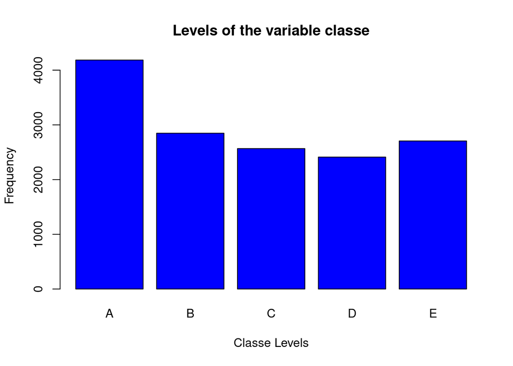

```r
plot(training$classe, col = "blue", main = "Levels of the variable classe",
     xlab = "Classe Levels", ylab = "Frequency")
```

Classe A is the most frequent, whereas classe D is the least frequent.

# Prediction Models

## Decision Tree

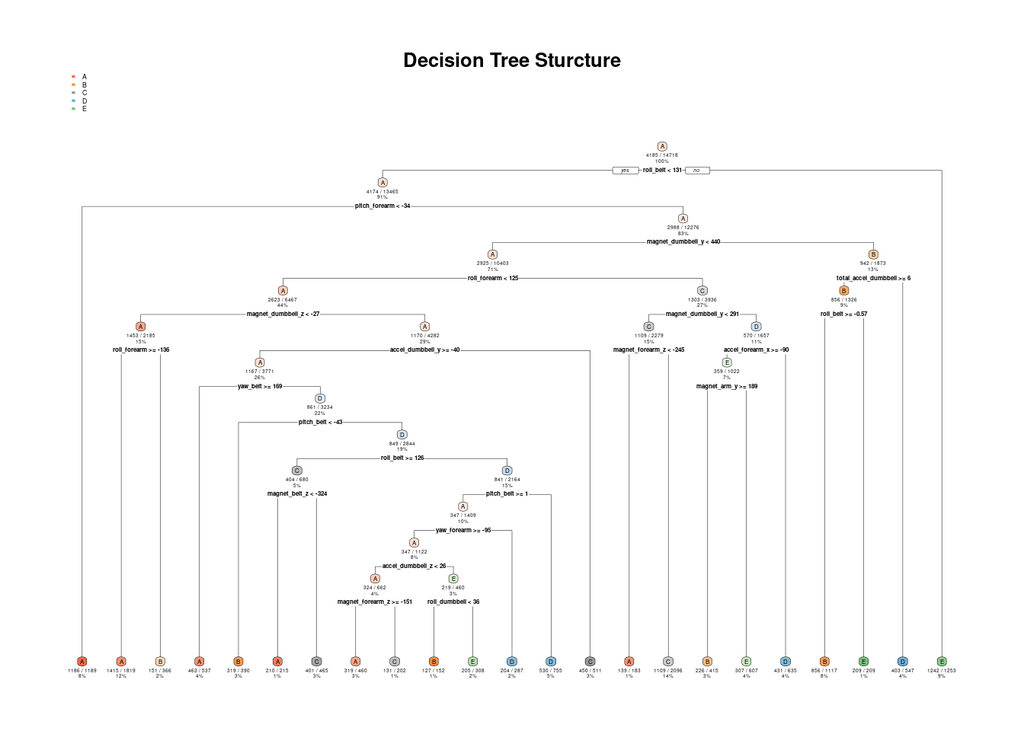

```r
# Fitting the model
decision_tree_fit <- rpart(classe ~ ., data = training, method = "class")

# Predicting using the model
decision_tree_prediction <- predict(decision_tree_fit, testing, type = "class")

# Plotting the result
rpart.plot(decision_tree_fit, main = "Decision Tree Sturcture",
           extra = 102, under = TRUE, faclen = 0)
```

### Confusion Matrix

```r
confusionMatrix(decision_tree_prediction, testing$classe)
```

```
## Confusion Matrix and Statistics
##
##           Reference
## Prediction    A    B    C    D    E
##          A 1251  149   15   61   17
##          B   38  572   75   60   75
##          C   39  117  696  117  122
##          D   49   58   51  508   58
##          E   18   53   18   58  629
##
## Overall Statistics
##
##                Accuracy : 0.7455
##                  95% CI : (0.7331, 0.7577)
##     No Information Rate : 0.2845
##     P-Value [Acc > NIR] : < 2.2e-16
##
##                   Kappa : 0.6774
##
##  Mcnemar's Test P-Value : < 2.2e-16
##
## Statistics by Class:
##
##                      Class: A Class: B Class: C Class: D Class: E
## Sensitivity            0.8968   0.6027   0.8140   0.6318   0.6981
## Specificity            0.9310   0.9373   0.9024   0.9473   0.9633
## Pos Pred Value         0.8379   0.6976   0.6379   0.7017   0.8106
## Neg Pred Value         0.9578   0.9077   0.9583   0.9292   0.9341
## Prevalence             0.2845   0.1935   0.1743   0.1639   0.1837
## Detection Rate         0.2551   0.1166   0.1419   0.1036   0.1283
## Detection Prevalence   0.3044   0.1672   0.2225   0.1476   0.1582
## Balanced Accuracy      0.9139   0.7700   0.8582   0.7896   0.8307
```

## Random Forest

```r
#Fitting the random forest model
random_forest_fit <- randomForest(classe ~., data = training, method = "class")

#Performing the prediction
random_forest_prediction <- predict(random_forest_fit, testing, type = "class")
```

### Confusion matrix

```r
confusionMatrix(random_forest_prediction, testing$classe)
```

```
## Confusion Matrix and Statistics
##
##           Reference
## Prediction    A    B    C    D    E
##          A 1395    4    0    0    0
##          B    0  944    8    0    0
##          C    0    1  847    6    0
##          D    0    0    0  798    1
##          E    0    0    0    0  900
##
## Overall Statistics
##
##                Accuracy : 0.9959
##                  95% CI : (0.9937, 0.9975)
##     No Information Rate : 0.2845
##     P-Value [Acc > NIR] : < 2.2e-16
##
##                   Kappa : 0.9948
##
##  Mcnemar's Test P-Value : NA
##
## Statistics by Class:
##
##                      Class: A Class: B Class: C Class: D Class: E
## Sensitivity            1.0000   0.9947   0.9906   0.9925   0.9989
## Specificity            0.9989   0.9980   0.9983   0.9998   1.0000
## Pos Pred Value         0.9971   0.9916   0.9918   0.9987   1.0000
## Neg Pred Value         1.0000   0.9987   0.9980   0.9985   0.9998
## Prevalence             0.2845   0.1935   0.1743   0.1639   0.1837
## Detection Rate         0.2845   0.1925   0.1727   0.1627   0.1835
## Detection Prevalence   0.2853   0.1941   0.1741   0.1629   0.1835
## Balanced Accuracy      0.9994   0.9964   0.9945   0.9961   0.9994
```

# Result and Conclusion

The Random Forest Model performs better than the Decision Tree Model. This is based on the higher accuracy achieved by the Random Forest Model.

## Submission

```r
# Perform Prediction
submission <- predict(random_forest_fit, testing_datafrane, type = "class")
submission
```

```
##  1  2  3  4  5  6  7  8  9 10 11 12 13 14 15 16 17 18 19 20
##  B  A  B  A  A  E  D  B  A  A  B  C  B  A  E  E  A  B  B  B
## Levels: A B C D E
```

```r
# Storing it to HD.
pml_write_files = function(x){
  n = length(x)
  for(i in 1:n){
    filename = paste0("./data/submission/problem_id_",i,".txt")
    write.table(x[i],file=filename,quote=FALSE,row.names=FALSE,col.names=FALSE)
  }
}
```